# Topic 10

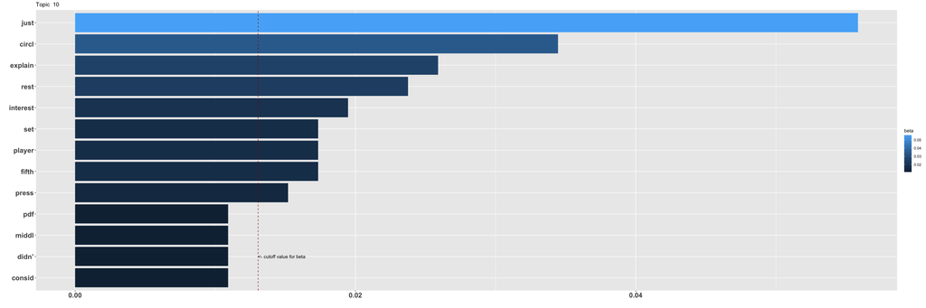

On interpreting beta: the term has a beta probability of being generated from the particular topic.

Values below are gamma : An estimated proportion of words from that document that are generated from that topic.

**Text Record Number: 510** gamma: 22 % likelihood of this document (based on its words) in this topic

**There have been a lot of good suggestions, but I’m a math person and think about it differently. If you’re a math person, you can just think about the circle of fifths as starting at C and going up 7 semitones until you get back to C again.

Alternatively, you can think of each note as a number (C = 0, C# = 1, D = 2, etc.), starting out at zero, and then adding 7 mod 12 until you get to 0 again; this is the same technique used as above.

If you know about algebra, Z_12 is cyclic and 7 is a generator of the group. Using the same idea (C = 0, C# = 1, D = 2 etc.), <7> will generate the circle of fifths in order. What’s really cool about this method is it’s extendable: Z_12 has four elements coprime to 12, so you might think well what do they correspond to?

<1> -> chromatic scale

<5> -> circle of fifths backwards

<7> -> circle of fifths

<11> -> chromatic scale backwards**

**Text Record Number: 559** gamma: 22 % likelihood of this document (based on its words) in this topic

**It’s just a description of the scale degrees.

Since ABCDEFGA ends back at A we call it a circle.

If A is one. B is 2 or a 2nd. From A, a 5th or the 5 would be E. But we can start counting from any point on the circle. If C is one. D is a 2nd and G is a 5th. So, G goes after C on the circle.

The circle is made up of all the Scale’s Root notes laid out in fifths instead of seconds(alphabet ordered).

Then you can visualize some differences like the 6th are relative minors of the roots and 4ths are the other direction…which probably makes no sense but visually it’s a geometrical eureka.**

**Text Record Number: 912** gamma: 22 % likelihood of this document (based on its words) in this topic

**If you were desperate, as in a teen buying a battery and a kitkat foil wrapper to light a joint. You could turn off the sound and listen to just the dynamics from you physically pressing the keys harder.

Otherwise, best to save for a decent keyboard/piano. It is a much easier skill than others to pick up, but you do need the audio feedback to be able to tell how loud the notes are from the pressure you use to press them.

Tbh it’s simple enough that if you learn pretty much three levels of f/p (basic loud/quiet) , mf/mp(slight steps louder/quieter) , fff/ppp(extremes of pressure), then being able to independently and simultaneously do that for multiple melodies (that bit’s hard actually) is basically it for most pieces. The hardest and professional level of dynamic control is honestly so subtle sometimes that for most pianists and pieces it doesn’t matter.

You won’t really be hindered in that you’ll develop bad habits, but you will need some practice at some point to be able to represent dynamics.

As others have said, if you get something that can detect pressure change, and has two/three pedals, you can physically practice most anything. Extra stuff is quality improvement.**

**Text Record Number: 1191** gamma: 22 % likelihood of this document (based on its words) in this topic

**I would really appreciate if you would be so kind and do another such video for some patterns in detail from 2 video examples I really ask myself since long what are they doing.

First video is [Lara example (unravel)](https://youtu.be/GsbX3_8eQfM)

I would love to have explained the pattern she’s roughly doing at 1.10 to 1.21 and then the pattern 1.22 to 1.48 in detail

And second video is [Hasit example (Janam Janam)](https://youtu.be/_qFKlwTxNjY) Roughly after 1.41 and after 2.08 What is he doing?

I would be incredibly grateful if you could explain and show slow these patterns in another video in detail. Your last video was so helpful 🤗🙏🏻

u/yeargdribble**

**Text Record Number: 402** gamma: 22 % likelihood of this document (based on its words) in this topic

**Someone once asked a famous jazz sax player, “ What goes through your mind before you solo?”

He answered, “Here we go.”

My point being that improvising is about being willing to let go of the editorial mind and just surrender to the music. You’d be amazed at the music that you can produce without thought.

You have to internalize music to the point that it becomes a language that you can speak without thinking about it. You don’t think about grammar when you talk. Just have fun in the discovery of new musical ‘words’ that resonate with you and use them until they become second nature. And listen. A lot.

Just my ten cents.**

**Text Record Number: 1055** gamma: 22 % likelihood of this document (based on its words) in this topic

**Separate hands at first, then slowly, very slowly even if it is one note at a time, you play together. You might feel extremely awkward and giggly at first but you do get used to it. Just be aware of what notes you are pressing and when you press them together, in time it will build up.

Hope that helps and you’ll do great**

**Text Record Number: 1309** gamma: 22 % likelihood of this document (based on its words) in this topic

**I’m told to think of the Circle of Fifths as, y’know, a circle, but that doesn’t really work for me unless I use pen and paper. Does anyone have any suggestions for this?**